```python
import matplotlib.pyplot as plt
import numpy as np
import pandas as pd
from sklearn.preprocessing import MinMaxScaler
from keras.models import Sequential
from keras.layers import Dense,Dropout,LSTM
from keras.layers import RepeatVector
from keras.layers import TimeDistributed
import cv2
```

### Auteur: GHEZAIEL Morad

# Bilan énergétique en tunisie: predictions via le deep learning

## Introduction:

Pour cette étude, j'ai récupéré plusieurs données liées au contexte énergetique de la tunisie de 1990 à 2018.

Parmi les features du dataset:

- **Production electrique par procédés:**
  - Turbines à vapeur
  - Turbines à gaz
  - Cycles combinés
  - Barrages
  - Eoliennes
  - Autoproductions
- **Par sociétés**:
  - Part STEG
  - Part IPP
- **Consommation electrique par types de lignes:**
  - Basse tension
  - Moyenne tension
  - Haute tension
- Petroliers: (en cours de construction)

Sources: *catalog.industrie.gov.tn/dataset/*

**Le but de cet étude et de modeliser le contexte énergétique tunisien via une approche LSTM à séries temporelles parallèles. Un intêret sera porté à l'evaluation du potentiel de transition énergétique du pays.**

## Chargement des données:

```python
data = pd.read_csv("data_energy.csv",sep=';')
data.iloc[:5,:]
```

|  | Year | TV(GWh) | TG(GWh) | CC(GWh) | Hyd.(GWh) | Eolienne(GWh) | Total STEG(GWh) | IPP (CC)(GWh) | Autoproducteurs(GWh) | Total(GWh) | ... | Consommation du secteur ?lectrique(ktep-pci) | Consommation pour usage finale(ktep-pci) | Import petrole( kt) | TOTAL(kt) | Zarzaitine (kt) | Ashtart (kt) | TOTAL (kt) | Ressources d'?nergie primaire(ktep-pci) | Demande d'?nergie primaire(ktep-pci) | Solde(ktep-pci) |
| --- | --- | --- | --- | --- | --- | --- | --- | --- | --- | --- | --- | --- | --- | --- | --- | --- | --- | --- | --- | --- | --- |
| 0 | 1990 | 3587 | 1267 | 0 | 45 | 0 | 4899 | 0 | 637 | 5536 | ... | 872 | 317 | 916 | 3212 | 3034 | 1477 | 4511 | 5394 | 4355,9 | 1038 |
| 1 | 1991 | 2037 | 2955 | 0 | 104 | 0 | 5096 | 0 | 648 | 5744 | ... | 503 | 339 | 917 | 3213 | 2742,73 | 2446,41 | 5189 | 6147 | 4337 | 1810 |
| 2 | 1992 | 4819 | 596 | 0 | 65 | 0 | 5479 | 0 | 702 | 6181 | ... | 854 | 378 | 918 | 3214 | 3261,42 | 1927 | 5188 | 6225 | 4716 | 1509 |
| 3 | 1993 | 4947 | 694 | 0 | 64 | 0 | 5705 | 0 | 608 | 6312 | ... | 797 | 402 | 919 | 3215 | 3022,53 | 1618,65 | 4641 | 5600 | 4839 | 760 |
| 4 | 1994 | 4380 | 645 | 966 | 40 | 0 | 6031 | 0 | 683 | 6714 | ... | 1266 | 422 | 920 | 3216 | 2822,26 | 1541,94 | 4364 | 5182 | 5123 | 59 |

5 rows × 24 columns

```python
[i for i in data.columns]
```

```
['Year',
 'TV(GWh)',
 'TG(GWh)',
 'CC(GWh)',
 'Hyd.(GWh)',
 'Eolienne(GWh)',
 ' Total STEG(GWh)',
 'IPP (CC)(GWh)',
 'Autoproducteurs(GWh)',
 'Total(GWh)',
 'HT(GWh)',
 'MT(GWh)',
 'BT(GWh)',
 'Total(GWh)_1',
 'Consommation du secteur ?lectrique(ktep-pci)',
 'Consommation pour usage finale(ktep-pci)',
 'Import petrole( kt)',
 'TOTAL(kt)',
 'Zarzaitine (kt)',
 'Ashtart (kt) ',
 'TOTAL (kt)',
 "Ressources d'?nergie primaire(ktep-pci)",
 "Demande d'?nergie primaire(ktep-pci)",
 'Solde(ktep-pci)']
```

## Visualisation des séries:

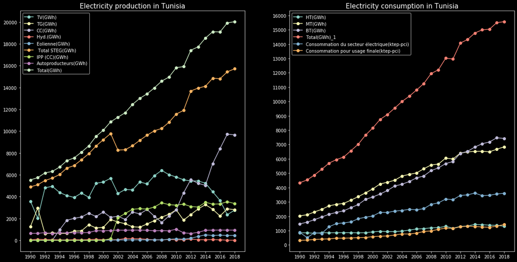

```python
## On stock le nom des features dans une liste
features = [i for i in data.columns]

## On split cette liste en production et consommation
electricity_production = features[1:10]
electricity_consumption = features[10:16]

## On creer un axe x pour les dates
dates = range(1990,2019)

## On initialise une figure
f = plt.figure(figsize=(20,10))

## Un background sombre pour faire plus "business"
plt.style.use(['dark_background'])

## On ajoute des plots à la figure
ax = f.add_subplot(121)

## Pour chaque features liées à la production
for i in electricity_production:

    # Crée le plot et le nomme
    ax.plot(dates,data[i],"-o",label=i)

## Met à jour la legende
ax.legend()

## Scale l'axe des x
ax.locator_params(nbins=20)


## Ajoute le titre
ax.set_title("Electricity production in Tunisia",fontsize=15)

## Idem pour la consommation
ax1 = f.add_subplot(122)
for i in electricity_consumption:
    ax1.plot(dates,data[i],"-o",label=i.replace("?","é"))
    ax1.legend()
    ax1.locator_params(nbins=20)
    ax1.set_title("Electricity consumption in Tunisia",fontsize=15,color="White")
```

## Modelisation:

Pour cette première partie, nous choisissons d'implementer un modele à entrée parallèles et à sorties multiples (LSTM encoder/decoder). Plus concretement nous poussons le modèle à encoder des informations partagées entre les series.  
Si la métrique d'évaluation d'un tel modèle est mauvaise, nous pouvons penser à:

- Une architecture qui n'est pas adéquate
- Des paramètres non adéquats
- Un nombre de données insufissant
- L'absence de relation entre les séries temporelles

### 1) Formattage des données :

Le modèle nécéssite d'organiser les données d'une certaine manière :

- Des echantillons d'entrée (une periode de temps à encoder)
- Des echantillons de sortie (la suite de cette même periode de temps)

Nous definissons ainsi une fonction permettant de generer les données d'entrainement pour une taille d'entrée et de sortie donnée:

```python
def split_sequences(sequences, n_steps_in, n_steps_out):
    X, y = list(), list()
    # Au fur et à mesure que l'on avance dans la sequence multivariées:
    for i in range(len(sequences)):
        # Nous definissons les bornes d'une fenetre d'entrée et de sortie
        end_ix = i + n_steps_in
        out_end_ix = end_ix + n_steps_out
        # Si les bornes de sorties sont superieures à la longueur de la sequence, on stoppe le decoupage
        if out_end_ix > len(sequences):
            break
        # Sinon on ajoute les entrées et les sorties à la liste
        seq_x, seq_y = sequences[i:end_ix, :], sequences[end_ix:out_end_ix, :]
        X.append(seq_x)
        y.append(seq_y)
    return np.array(X), np.array(y)
```

On reorganise les données pour alimenter le reseau.

On defini également la taille des fenetres d'entrée et de sortie:

```python
## On stock les données de consommation et de production dans des listes
prod_ts = [np.array(data[i].values).reshape((len(np.array(data[i].values)), 1))
           for i in electricity_production]
cons_ts = [np.array(data[i].values).reshape((len(np.array(data[i].values)), 1))
           for i in electricity_consumption]

## On en crée une composées des deux pendants
both_ts = prod_ts+cons_ts

## Les données étaient classée par features, on les convertit en échantillons
prod_ts_stack = np.hstack(prod_ts)
cons_ts_stack = np.hstack(cons_ts)
both_ts_stack = np.hstack(both_ts)

## On utilisera le jeu composé des deux pendants pour le modèle ##

## Initialise la taille des fenètres
n_steps_in, n_steps_out = 5, 3

## On scale les données pour obtenir une erreur interprétable
scaler = MinMaxScaler(feature_range=(0,1))
scaler.fit(both_ts_stack)
both_ts_stack_scaled = scaler.transform(both_ts_stack)

# On creer le jeu de données en appellant la fonction précédente
X, y = split_sequences(both_ts_stack_scaled, n_steps_in, n_steps_out)

# On defini le nombre de features
n_features = X.shape[2]
```

### 2) Initialisation du modèle

Le modèle sera constitué d'un couche LSTM de 300 unités (encoder) dont la sortie correspondra à un vecteur unique de taille N*nombre de sortie (ici 3). Cette forme encodée de l'information sera capté par une couche LSTM de 300 unités (decoder) entrainée à reproduire les vecteurs de sorties. Finalement, nous utilisons la "meta-couche" TimeDistributed correspondant à une couche de n_features* n_sorties poids mis à jour en même temps durant l'entrainement (de la sorte, la precision de chaque sorties est identique à chaque batch). Nous utilisons finalement des activation relu pour l'encoder et le decoder afin de favoriser de l'information pertinente (noeud contreproductifs passés à zero = j'oublie ce qui ne me sert à rien). L'algorithme d'optimisation ADAM est utile quand nous choisissons des activations relu (la back propagation converge plus vite en presence de noeuds à zeros). Finalement, le modèle sera évalué en mesurant la moyenne des erreurs au carré = MSE.

```python
# On definit le modele
model = Sequential()
model.add(LSTM(300, activation='relu', input_shape=(n_steps_in, n_features)))
model.add(RepeatVector(n_steps_out))
model.add(LSTM(300, activation='relu', return_sequences=True))
model.add(TimeDistributed(Dense(n_features)))
model.compile(optimizer='adam', loss='mse')
# On fit le modèle
history = model.fit(X, y, epochs=500, batch_size=50)
```

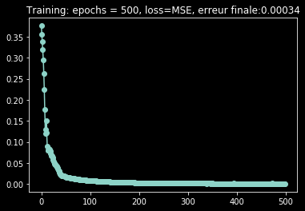

```python
## Learning curve
loss = history.history["loss"]
plt.plot(range(len(loss)),loss,"-o")
plt.title('Training: epochs = 500, loss=MSE, erreur finale:{}'.format(round(loss[-1],5)))
```

```python
# Predictions
x_input = np.array([both_ts_stack_scaled[len(both_ts_stack_scaled)-n_steps_in:len(both_ts_stack_scaled)]])

yhat = model.predict(x_input, verbose=0)

yhat_uns = scaler.inverse_transform([i for i in yhat[0]])

both_ts_stack = both_ts_stack.tolist()

for year in range(len(yhat_uns)):
    both_ts_stack.append([int(i) for i in yhat_uns[year]])

both_ts_stack = np.dstack(both_ts_stack)
```

### 3) Resultats

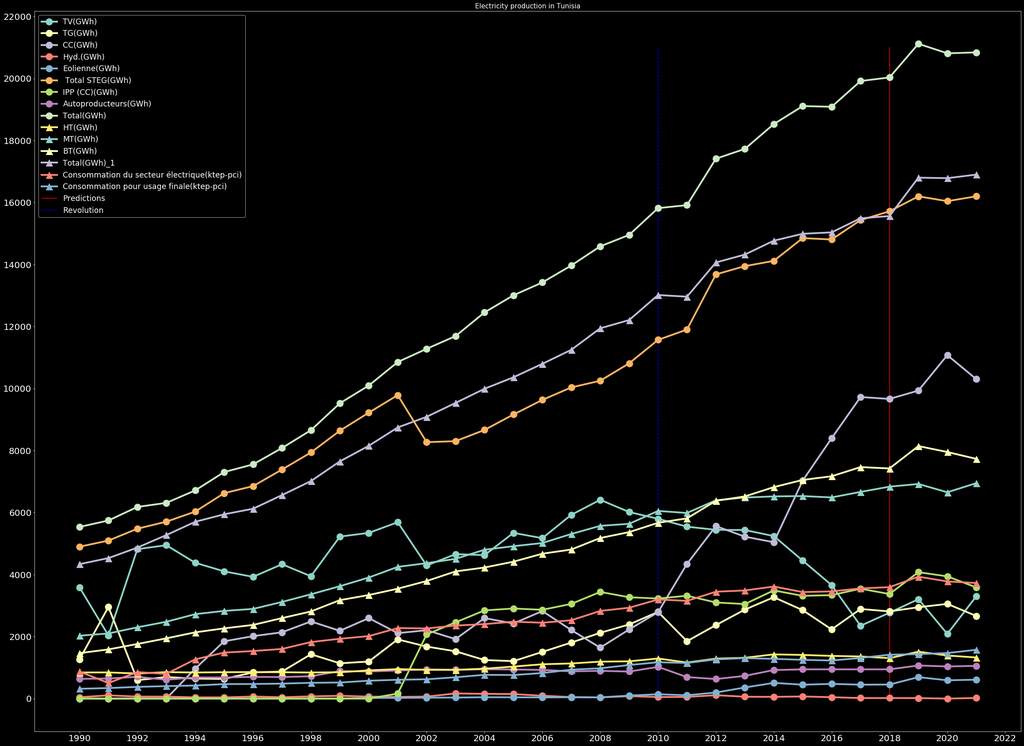

```python
dic = {features[1:16][i]:both_ts_stack[0][i] for i in range(len(both_ts_stack[0]))}

dates = range(1990,2019+n_steps_out)
f = plt.figure(figsize=(40,30))
#plt.style.use(['dark_background'])
ax = f.add_subplot(111)
ax.vlines(ymin=0,ymax=21000,x=2018,color="red",label="Predictions")
ax.vlines(ymin=0,ymax=21000,x=2010,color="blue",linestyle="dashed",label="Revolution")
for i in features[1:16]:
    if features[1:16].index(i)<9:
        marker = "-o"
    else:
        marker = "-^"
    ax.plot(dates,dic[i],marker,label=i.replace("?","é"),linewidth=4,markersize=15)
    ax.locator_params(nbins=18)
    ax.set_title("Electricity production in Tunisia",fontsize=15)
plt.xticks(fontsize=20)
plt.yticks(fontsize=20)
ax.legend(fontsize="xx-large")
```

Etant donné les prévisions de l'augmentation du cout du gaz dans les futures années, il est évident que la tunisie doit se defaire de sa dependance au gaz. Bien évidemment, le gisement naturel d'Al Borma et le Trans-Mediterranean Pipeline sont des sources de gaz importantes pour le pays. Cependant les gisements offshores Miskar et Hasdrubal, responsable de l'augmentation de la production du gaz en 2000 sont actuellement en declins.

Si les cycles combinés se sont révélés efficace pour compenser la dependance au gaz, il n'en reste pas moins dependant. En observant les previsions du modèle pour l'année 2021, on observe une réaugmentation de l'utilisation des turbines à vapeur qui semblent pouvoir compenser les importantes diminutions observées dans la production d'electricité via turbines à gaz et cycle combinés.

Finalement, cet exemple de modelisation indique une importance de la transition energétique pour l'avenir de la tunisie. La part des énergies renouvelables n'est pas suffisante et devrait être develloppées dans les prochaines années. Afin de supporter l'evolution du cout du gaz et de favoriser le developpement des energies renouvelable, la tunisie devrait compter sur les turbines à vapeur et les cycles combinés : le rapport sur investissement/temps est le moins important (cf figure ci-dessous).

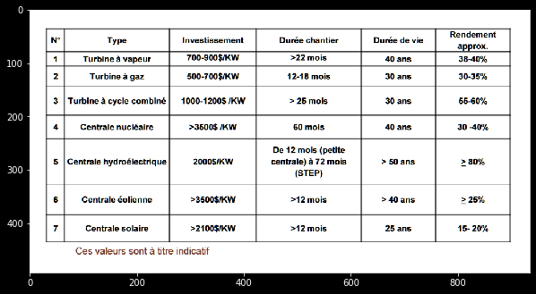

```python
invest = cv2.imread("Invest..png")
f = plt.figure(figsize=(10,10))
ax = f.add_subplot(111)
ax.imshow(invest)
```

### Futurs travaux:

- Features importance
- Weight convergence study to improve the model